# B站高收藏健身视频特征分析

狗熊会

案例背景：如今，越来越多的人开始注重锻炼身体和身材管理，主动积极参与到不同的体育运动中。此外，由于疫情居家，许多人转向了更为简便的居家运动，一张瑜伽垫、一块屏幕，便可以开始运动。B站作为众多健身、运动Up主源源不断输出作品的平台，为运动爱好者们提供了许多资源，如跟练视频、器械教程、运动教学等。同时，B站作为具有代表性的视频软件之一，拥有海量视频和创作者，各类别的视频都具有充足的样本量，可获取的研究指标如播放量、收藏数、作者粉丝量等也十分丰富，是良好的研究对象。因此，本案例以B站中的部分健身视频为研究对象，希望对现有健身视频画像，更好了解行业特征，在健身者面对琳琅满目、五花八门的健身视频时，提供优良的选择建议；并分析高收藏健身视频特征，为Up主们产出高质量、更受欢迎的健身跟练视频提供精细化建议。

这个案例的学习目标包括：

1.了解B站视频分析的基本要素如点赞、投币、收藏等，学习基础的数据操作和数据可视化方法。

2.学习如何对标签数据进行分析。

3.学习如何计算标题信息度量得分。

4.学习在Python中建立LDA主题模型的基本方法。

5.学习如何在Python中使用逻辑回归进行建模。

# 准备工作

```python
# 导入需要的程序包

# 基础程序包
import numpy as np
import pandas as pd
import warnings
warnings.filterwarnings("ignore") # 不显示warnings信息

# 文本预处理
import codecs
import jieba
from functools import reduce
from snownlp import SnowNLP
import re,string
import collections
from collections import Counter #统计词频


# 主题模型
import gensim
from gensim.models.coherencemodel import CoherenceModel
from gensim.models.ldamodel import LdaModel
from gensim.corpora import Dictionary
import nltk
from nltk.stem import WordNetLemmatizer
from nltk import FreqDist
from nltk.corpus import stopwords
from nltk import WordNetLemmatizer, pos_tag, word_tokenize

# 信息量度量
from sklearn.feature_extraction import DictVectorizer
from sklearn.feature_extraction.text import TfidfTransformer  #计算TF-IDF
from sklearn.feature_extraction.text import CountVectorizer
from scipy import stats
from scipy.stats import norm

# 画图
import matplotlib as mpl
import matplotlib.pyplot as plt
import matplotlib.colors as mcolors
import seaborn as sns
from matplotlib import pyplot as plt
from wordcloud import WordCloud, STOPWORDS
import statsmodels.api as sm
```

# 任务一

在该任务中，我们尝试读入数据并了解数据的变量构成。请在工作目录下找到"data.csv"文件，读入该数据，并且展示数据的前5行，观察一下数据的基本情况。

提示：数据读入可以使用pd.read_csv。

在该数据中，视频收藏数是我们关心的因变量，绘制该变量的直方图，观察其分布情况。

```python
# 读入原始数据
data = pd.read_csv('data.csv',encoding = 'utf-8')
```

```python
# 看一眼数据中有什么
data.head(5)
```

|  | web-scraper-order | web-scraper-start-url | play | barrage | first_link | first_link-href | zan | toubi | shoucang | zhuanfa | second_link | second_link-href | fans | shipinshu | tag | hour | minute | second | publictime | shipin_minute |
| --- | --- | --- | --- | --- | --- | --- | --- | --- | --- | --- | --- | --- | --- | --- | --- | --- | --- | --- | --- | --- |
| 0 | 1635500234-305 | https://www.bilibili.com/v/sports/aerobics/?sp... | 86000 | 43 | [Coffee林芊妤]給初階者的45分鐘基礎瑜伽班 | https://www.bilibili.com/video/BV1fh411q7bt | 1178 | 306 | 4069 | 218 | CoffeeLam | https://space.bilibili.com/304020239 | 286000 | 145 | 瑜伽减肥健身运动健身\r 运动\r \r ... | 0 | 48 | 5 | 84 | 48.083333 |
| 1 | 1635499417-208 | https://www.bilibili.com/v/sports/aerobics/?sp... | 225000 | 163 | 忙碌一天，回到家，打开门…… | https://www.bilibili.com/video/BV1XU4y157yN | 18000 | 247 | 3418 | 1670 | 狼森森 | https://space.bilibili.com/5500182 | 48000 | 38 | 健身运动健身\r 瘦身塑形\r \r 肌肉 | 0 | 0 | 8 | 134 | 0.133333 |
| 2 | 1635500132-291 | https://www.bilibili.com/v/sports/aerobics/?sp... | 329000 | 218 | 搓衣板 | https://www.bilibili.com/video/BV1PU4y1n7ea | 14000 | 443 | 3951 | 2068 | 独hero | https://space.bilibili.com/344924352 | 2985 | 6 | 运动健身\r 全民健身征集令\r \r 帅... | 0 | 0 | 10 | 83 | 0.166667 |
| 3 | 1635571010-1195 | https://www.bilibili.com/v/sports/aerobics/?sp... | 105000 | 26 | 运动vs正装，你喜欢哪个？ | https://www.bilibili.com/video/BV1Xf4y1b7Cc | 1817 | 83 | 931 | 39 | 鲈鱼suittttt | https://space.bilibili.com/87660474 | 18000 | 136 | 健身运动健身\r 性感\r \r VLOG... | 0 | 0 | 10 | 151 | 0.166667 |
| 4 | 1635571147-1208 | https://www.bilibili.com/v/sports/aerobics/?sp... | 214000 | 14 | 这哥们是刚结束？ | https://www.bilibili.com/video/BV1af4y1j7zn | 2316 | 70 | 942 | 63 | 学长长长 | https://space.bilibili.com/1351095779 | 6156 | 42 | 运动健身\r 帅哥\r \r 性感\r ... | 0 | 0 | 10 | 99 | 0.166667 |

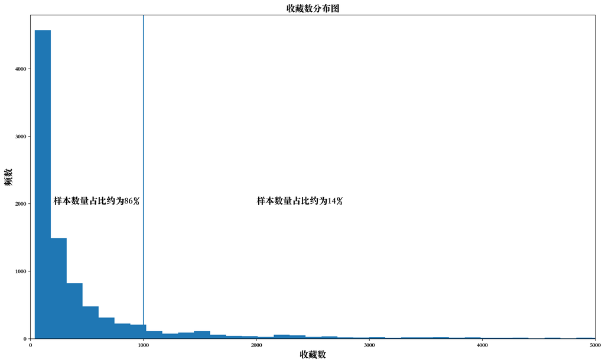

```python
# 绘图观察收藏数的分布情况
# 设置画图所需参数
plt.rcParams['font.family']='Songti SC'
plt.rcParams['font.sans-serif']=['Songti SC'] #用来正常显示中文标签
plt.rcParams['axes.unicode_minus']=False #用来正常显示负号
plt.rcParams['figure.dpi']=200 #分辨率

fig,ax = plt.subplots(figsize=(17,10))
ax.hist(data['shoucang'],bins=1000)
ax.axvline(1000) # 以1000为界进行划分
ax.set_xlim(0,5000)
ax.set_xlabel('收藏数',fontsize=15)
ax.set_ylabel('频数',fontsize=15)
ax.text(2000,2000,'样本数量占比约为14%', fontsize=15) # 设置左侧注释
ax.text(200,2000,'样本数量占比约为86%', fontsize=15) # 设置右侧注释
plt.title('收藏数分布图', fontsize=15)
plt.show()
```

# 任务二

在该任务中，对视频标题和标签数据进行处理。读取中文停用词文本信息，根据爬取的数据特点，在jieba数据库中加入"减脂"、"创作营"、"弹力带"、"直男"、"马甲线"、"拜拜肉"、"深蹲"、"大基数"这8个新型词汇，在停用词列表中加入"月"、"中"、"完"这3个出现频次较高且无实义的词汇。在此上述处理的基础上，对于数据中的标签和标题进行分词处理（去除停用词，统计jieba词库的词语），统计标签词语个数作为新的一个变量，并对处理后的数据进行展示前5行。

提示：可以使用jieba.add_word函数向jieba库加入词汇；可以使用collections.Counter完成词频统计；可以使用TfidfTransformer计算词语的TF-IDF值。

```python
# 读取中文停用词表并进行处理
stop_word = []
with open("中文停用词.txt", "r") as f:
    for line in f.readlines():
        line = line.strip('\n')
        stop_word.append(line)

jieba.add_word("减脂")
jieba.add_word("创作营")
jieba.add_word("弹力带")
jieba.add_word("直男")
jieba.add_word("马甲线")
jieba.add_word("拜拜肉")
jieba.add_word("深蹲")
jieba.add_word("大基数")

punc = '~`!#$%^&*()_+-=|\';":/.,?><~·！@#￥%……&*（）——+-=“：’；、。，？》｜《{}Q【】 '
stop_word.append("月")
stop_word.append("中")
stop_word.append("完")
```

```
Building prefix dict from the default dictionary ...
Loading model from cache /var/folders/pz/ckvgvvfj50l8yhxwjv7_swsh0000gn/T/jieba.cache
Loading model cost 0.684 seconds.
Prefix dict has been built successfully.
```

```python
# 对视频标题和标签进行分词处理
tag = []
name = []
tag_num = []
corpus  = []
object_list1 = []
object_list2 = []
data['tag']=data['tag'].str.replace(" ","")
data['tag']=data['tag'].str.replace("\n","")
for i in range(data.shape[0]):
    s1 = jieba.cut(re.sub(r"[%s]+" %punc, "", data['first_link'][i]), cut_all=False)
    s2 = jieba.cut(data['tag'][i], cut_all=False)
    word1 = ",".join(s1).split(',')
    word2 = ",".join(s2).split(',')
    s = SnowNLP(data['first_link'][i])
    name.append(word1) # 标题分词
    tag.append(word2) # 标签分词
    tag_num.append(len(word2)) # 计算标签个数
    corpus.append(" ".join(word1)) # 关键词语料
    for w in word1: # 循环读出每个分词
        if w not in stop_word: # 如果不在去除词库中
            object_list1.append(w)
    for w in word2: # 循环读出每个分词
        if w not in stop_word: # 如果不在去除词库中
            object_list2.append(w)
data['tag_num'] = tag_num
data.head(5)
```

|  | web-scraper-order | web-scraper-start-url | play | barrage | first_link | first_link-href | zan | toubi | shoucang | zhuanfa | ... | second_link-href | fans | shipinshu | tag | hour | minute | second | publictime | shipin_minute | tag_num |
| --- | --- | --- | --- | --- | --- | --- | --- | --- | --- | --- | --- | --- | --- | --- | --- | --- | --- | --- | --- | --- | --- |
| 0 | 1635500234-305 | https://www.bilibili.com/v/sports/aerobics/?sp... | 86000 | 43 | [Coffee林芊妤]給初階者的45分鐘基礎瑜伽班 | https://www.bilibili.com/video/BV1fh411q7bt | 1178 | 306 | 4069 | 218 | ... | https://space.bilibili.com/304020239 | 286000 | 145 | 瑜伽减肥健身运动健身\r运动\r\r瘦身\r\r减脂\r\r塑形\r\rYOGA | 0 | 48 | 5 | 84 | 48.083333 | 18 |
| 1 | 1635499417-208 | https://www.bilibili.com/v/sports/aerobics/?sp... | 225000 | 163 | 忙碌一天，回到家，打开门…… | https://www.bilibili.com/video/BV1XU4y157yN | 18000 | 247 | 3418 | 1670 | ... | https://space.bilibili.com/5500182 | 48000 | 38 | 健身运动健身\r瘦身塑形\r\r肌肉 | 0 | 0 | 8 | 134 | 0.133333 | 8 |
| 2 | 1635500132-291 | https://www.bilibili.com/v/sports/aerobics/?sp... | 329000 | 218 | 搓衣板 | https://www.bilibili.com/video/BV1PU4y1n7ea | 14000 | 443 | 3951 | 2068 | ... | https://space.bilibili.com/344924352 | 2985 | 6 | 运动健身\r全民健身征集令\r\r帅哥\r\r瘦身\r\r腹肌\r\r肌肉 | 0 | 0 | 10 | 83 | 0.166667 | 19 |
| 3 | 1635571010-1195 | https://www.bilibili.com/v/sports/aerobics/?sp... | 105000 | 26 | 运动vs正装，你喜欢哪个？ | https://www.bilibili.com/video/BV1Xf4y1b7Cc | 1817 | 83 | 931 | 39 | ... | https://space.bilibili.com/87660474 | 18000 | 136 | 健身运动健身\r性感\r\rVLOG\r\r室友\r\r正装 | 0 | 0 | 10 | 151 | 0.166667 | 13 |
| 4 | 1635571147-1208 | https://www.bilibili.com/v/sports/aerobics/?sp... | 214000 | 14 | 这哥们是刚结束？ | https://www.bilibili.com/video/BV1af4y1j7zn | 2316 | 70 | 942 | 63 | ... | https://space.bilibili.com/1351095779 | 6156 | 42 | 运动健身\r帅哥\r\r性感\r\r荷尔蒙\r\r腹肌\r\r体育生 | 0 | 0 | 10 | 99 | 0.166667 | 17 |

5 rows × 21 columns

```python
# 对标题和标签的分词结果进行词频统计，并输出标题出现频次前20高的词语及相应的个数。
word_counts1 = collections.Counter(object_list1) # 对标题分词做词频统计
title_counts_top20 = word_counts1.most_common(20) # 获取前20最高频的词
word_counts2 = collections.Counter(object_list2) # 对标签分词做词频统计
tag_counts_top20 = word_counts2.most_common(20) # 获取前20最高频的词
print(title_counts_top20) # 输出检查
```

```
[('训练', 1275), ('健身', 906), ('分钟', 795), ('动作', 603), ('减肥', 597), ('运动', 536), ('瑜伽', 532), ('瘦', 530), ('燃脂', 429), ('腿', 427), ('练', 425), ('肌肉', 410), ('减脂', 410), ('臀', 313), ('做', 309), ('腹肌', 280), ('全身', 275), ('拉伸', 270), ('改善', 267), ('跳绳', 248)]
```

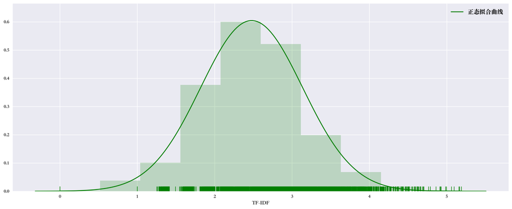

```python
# 将标题文本中的词语转换为词频矩阵，并利用TfidfTransformer函数计算各个词语的TI-IDF权重，并对标题中包含的所有词语的TI-IDF值进行加和计算作为新的一个变量，即衡量每个标题的信息量。
vectorizer = CountVectorizer() # 该类会将文本中的词语转换为词频矩阵，矩阵元素a[i][j] 表示j词在i类文本下的词频
transformer = TfidfTransformer() # 该类会统计每个词语的tf-idf权值
# 第一个fit_transform是计算tf-idf，第二个fit_transform是将文本转为词频矩阵
tfidf = transformer.fit_transform(vectorizer.fit_transform(corpus))
all_word = vectorizer.get_feature_names() # 获取词袋模型中的所有词语
# 将tf-idf矩阵抽取出来，元素a[i][j]表示j词在i类文本中的tf-idf权重
weight = tfidf.toarray()
score = np.sum(weight, axis=1) # 信息度量得分
data['key_score'] = score

# 绘制标题信息量的直方图，观察所有标题信息量的分布情况
plt.style.use('seaborn')
plt.rcParams['figure.figsize'] = (18,7) # 设置大小
plt.rcParams['font.family']='Songti SC'
plt.rcParams['font.sans-serif']=['Songti SC'] #用来正常显示中文标签
sns.distplot(data['key_score'], color = 'green', rug=True, bins=10, kde= False,fit= norm,
             hist_kws = { 'linewidth':1, 'alpha':0.2},
             fit_kws={'color':'green'})
# plt.title('Variations in key_score', fontsize = 20)
plt.xlabel('TF-IDF')
# plt.ylabel('概率')

leg = plt.legend(["正态拟合曲线"],loc = 'best',fontsize='large')
for text in leg.get_texts(): # 改变label文字颜色
    plt.setp(text, color = 'black')
plt.savefig("信息度量得分")
plt.show()
```

# 任务三

在该任务中，建立LDA主题情感模型，对视频标题进行分类，并使用可视化方法展示LDA模型的结果。

提示：分词可以使用jieba包中的lcut函数；使用gensim.corpora.Dictionary函数建立语料库；建立LDA主题模型可以使用LdaModel函数。

```python
# 对视频标题进行分词并储存分词结果
def filter_stopwords(txt):
    txt = re.sub(r'[^\u4e00-\u9fa5]+','',txt) #去掉非中文字符
    sent = jieba.lcut(txt)
    words = []
    for word in sent:
        if(word in stop_word):
            continue
        else:
            words.append(word)
    return words

data["cont"] = data["first_link"].astype(str).apply(filter_stopwords)
data["cont"].head()
```

```
0    [林芊妤, 給初, 階者, 分鐘, 基礎, 瑜伽, 班]
1                [忙碌, 回到, 家, 打开门]
2                           [搓衣板]
3                    [运动, 正装, 喜欢]
4                        [哥们, 结束]
Name: cont, dtype: object
```

```python
# 存入语料库
dictionary_bili = gensim.corpora.Dictionary(data.cont)
dictionary_bili.filter_extremes(no_below=5)
corpus_bili = [dictionary_bili.doc2bow(doc) for doc in data.cont]
```

```python
# 建立LDA主题模型
num_topics = 8 # 设置主题数
model = LdaModel(corpus=corpus_bili, id2word=dictionary_bili, num_topics=num_topics,
                       passes=5, random_state=100)
topic_list = model.print_topics(20)
for topic in topic_list:
    print(topic) # 打印主题
```

```
(0, '0.084*"健身" + 0.057*"训练" + 0.024*"天" + 0.023*"日常" + 0.018*"计划" + 0.015*"健身房" + 0.015*"挑战" + 0.014*"年" + 0.014*"背部" + 0.013*"教练"')
(1, '0.051*"训练" + 0.032*"腹肌" + 0.027*"减肥" + 0.024*"动作" + 0.018*"斤" + 0.017*"瘦" + 0.016*"分享" + 0.014*"真的" + 0.013*"练" + 0.012*"练出"')
(2, '0.051*"燃脂" + 0.042*"减肥" + 0.026*"减脂" + 0.026*"跳" + 0.026*"新手" + 0.025*"有氧" + 0.021*"燃脂舞" + 0.020*"暴汗" + 0.020*"分钟" + 0.018*"合集"')
(3, '0.032*"肌肉" + 0.026*"吃" + 0.023*"训练" + 0.017*"运动" + 0.016*"体育" + 0.013*"动作" + 0.012*"减肥" + 0.012*"变化" + 0.011*"生" + 0.011*"男人"')
(4, '0.072*"瑜伽" + 0.041*"臀" + 0.041*"训练" + 0.038*"分钟" + 0.022*"锻炼" + 0.022*"手臂" + 0.020*"练" + 0.018*"臀部" + 0.017*"动作" + 0.015*"拉伸"')
(5, '0.029*"瘦" + 0.028*"腿" + 0.025*"分钟" + 0.024*"运动" + 0.021*"改善" + 0.015*"做" + 0.013*"动作" + 0.013*"肌肉" + 0.012*"拉伸" + 0.012*"膝盖"')
(6, '0.045*"跳绳" + 0.025*"健美" + 0.023*"俯卧撑" + 0.023*"身材" + 0.022*"健身" + 0.019*"肌肉" + 0.019*"跑步" + 0.016*"岁" + 0.016*"动作" + 0.013*"展示"')
(7, '0.028*"自用" + 0.026*"系列" + 0.017*"脂肪" + 0.015*"分钟" + 0.015*"喜欢" + 0.013*"帕梅拉" + 0.013*"音乐" + 0.011*"老师" + 0.010*"跟练" + 0.010*"高强度"')
```

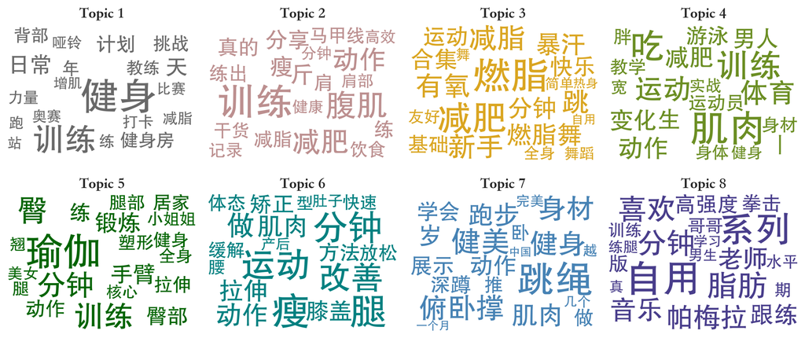

```python
# LDA结果可视化
font = 'FZHTJW.ttf' # 读取字体
cols = list(['#696969','#BC8F8F','#DAA520','#6B8E23','#006400',"#008080","#4682B4","#483D8B","#663399","#8B008B","#af2f0d","#c9643b","#cb7723","#029386","#748500"])
# cols = [color for name, color in mcolors.CSS4_COLORS.items()]  # more colors: 'mcolors.XKCD_COLORS' "mcolors.TABLEAU_COLORS"
# 选择主题颜色

cloud = WordCloud(background_color='white',
                  width=2500,
                  height=1800,
                  max_words=20,
                  colormap='tab10',
                  color_func=lambda *args, **kwargs: cols[i],
                  prefer_horizontal=1.0,
                  font_path=font )

topics = model.show_topics(formatted=False,num_words=20,num_topics=num_topics)

fig, axes = plt.subplots(2,4, figsize=(12,8), sharex=True, sharey=True)  #如果修改主题数，注意这里的修改

for i, ax in enumerate(axes.flatten()):
    if i == num_topics:
        fig.add_subplot(ax)
        plt.gca().axis('off')
        break
    fig.add_subplot(ax)
    topic_words = dict(topics[i][1])
    cloud.generate_from_frequencies(topic_words, max_font_size=500)
    plt.gca().imshow(cloud)
    plt.gca().set_title('Topic ' + str(i+1), fontdict=dict(size=16))
    plt.gca().axis('off')

plt.subplots_adjust(wspace=1, hspace= -0.5)
plt.axis('off')
plt.margins(x=0, y=0)
plt.tight_layout()
plt.savefig('LDA_title_%d.jpg'%num_topics,bbox_inches='tight', quality=95)
plt.show()
```

# 任务四

1.因变量标注。综合样本分布情况，以收藏数1000为界将全体视频分为两类，将收藏数高于1000的视频标注为“高收藏类”，将收藏数小于等于1000的视频标注为“低收藏类”;

2.将LDA结果设置哑变量。将LDA主题分类结果纳入自变量中，并根据dominant的主题确定每只视频所对应的LDA主题类别。将主题类别转换为哑变量，并将topic1作为基准类别，删去topic1一列;

提示：建立逻辑回归模型可以使用sm.Logit函数。

```python
# 读取带LDA结果的数据集
data_LDA = pd.read_csv('data_topicin_prob_1123.csv')
data_LDA.describe()
```

|  | play | barrage | zan | toubi | shoucang | zhuanfa | fans | shipinshu | hour | minute | ... | shipin_minute | s_len | Topic 1 | Topic 2 | Topic 3 | Topic 4 | Topic 5 | Topic 6 | Topic 7 | Topic 8 |
| --- | --- | --- | --- | --- | --- | --- | --- | --- | --- | --- | --- | --- | --- | --- | --- | --- | --- | --- | --- | --- | --- |
| count | 9.354000e+03 | 9354.000000 | 9354.000000 | 9354.000000 | 9354.000000 | 9354.000000 | 9.354000e+03 | 9354.000000 | 9354.000000 | 9354.000000 | ... | 9354.000000 | 9354.000000 | 9354.000000 | 9354.000000 | 9354.000000 | 9354.000000 | 9354.000000 | 9354.000000 | 9354.000000 | 9354.000000 |
| mean | 3.677426e+04 | 68.757858 | 1364.172653 | 283.065106 | 823.635022 | 119.144751 | 4.845945e+04 | 158.162925 | 0.135985 | 6.228458 | ... | 14.867811 | 23.822536 | 0.122876 | 0.128205 | 0.128640 | 0.127091 | 0.116701 | 0.135141 | 0.124472 | 0.116874 |
| std | 1.351477e+05 | 378.451903 | 8436.504619 | 2235.591709 | 3727.224822 | 640.289876 | 1.710425e+05 | 286.050210 | 2.188269 | 9.214056 | ... | 133.049490 | 13.297392 | 0.190223 | 0.191678 | 0.188292 | 0.191591 | 0.174924 | 0.195898 | 0.189451 | 0.180693 |
| min | 1.100000e+02 | 0.000000 | 3.000000 | 0.000000 | 39.000000 | 0.000000 | 1.000000e+00 | 0.000000 | 0.000000 | 0.000000 | ... | 0.050000 | 1.000000 | 0.004633 | 0.003908 | 0.003911 | 0.004467 | 0.003910 | 0.003917 | 0.004466 | 0.003908 |
| 25% | 3.281250e+03 | 1.000000 | 87.000000 | 12.000000 | 86.000000 | 7.000000 | 2.283250e+03 | 41.000000 | 0.000000 | 1.000000 | ... | 1.666667 | 15.000000 | 0.017862 | 0.017863 | 0.017863 | 0.017865 | 0.017862 | 0.017863 | 0.017871 | 0.017865 |
| 50% | 9.143000e+03 | 7.000000 | 239.000000 | 36.000000 | 189.000000 | 18.000000 | 9.891000e+03 | 87.000000 | 0.000000 | 3.000000 | ... | 3.675000 | 22.000000 | 0.031253 | 0.031254 | 0.031257 | 0.031258 | 0.031254 | 0.031257 | 0.031255 | 0.031253 |
| 75% | 2.600000e+04 | 32.000000 | 700.750000 | 119.750000 | 495.750000 | 57.000000 | 3.800000e+04 | 178.000000 | 0.000000 | 7.000000 | ... | 7.950000 | 30.000000 | 0.138898 | 0.162262 | 0.170451 | 0.156868 | 0.141900 | 0.187421 | 0.146442 | 0.125000 |
| max | 4.588000e+06 | 14000.000000 | 476000.000000 | 127000.000000 | 141000.000000 | 30000.000000 | 8.510000e+06 | 11683.000000 | 55.000000 | 59.000000 | ... | 3302.000000 | 84.000000 | 0.967582 | 0.956238 | 0.927036 | 0.937414 | 0.937494 | 0.927054 | 0.948511 | 0.937464 |

8 rows × 22 columns

```python
# 以1000为界将全体视频分为两类
data_LDA['shoucang1']=np.where(data_LDA['shoucang']>1000,1,0)

# 由于粉丝数与up主视频数两个变量取值较大，与其余变量量纲存在较大差异，因此进行单位矫正
data_LDA['fans1']=np.array(data_LDA['fans'])/1000
data_LDA['shipinshu1']=np.array(data_LDA['shipinshu'])/10

# 将LDA主题分类结果纳入自变量中，并设置哑变量
vec = DictVectorizer(sparse=False)
feature = data_LDA[['Dominant']]
X = vec.fit_transform(feature.to_dict(orient='records'))#to_dict将dataframe转换为dict
topic = pd.DataFrame(X,columns=['Topic1','Topic2','Topic3','Topic4','Topic5','Topic6','Topic7','Topic8'])

# 将某一topic作为基准
topic.drop(['Topic1'],inplace=True,axis=1)
print(topic) # 展示主题结果

# 合并其余变量
total = pd.concat([data_LDA[['web-scraper-order','fans1','shipinshu1','publictime','shipin_minute','shoucang1']],topic],axis=1)

# 加入信息量得分和tag_num
total = pd.merge(total,data[['web-scraper-order','tag_num','key_score']],how='left')
```

```
      Topic2  Topic3  Topic4  Topic5  Topic6  Topic7  Topic8
0        0.0     0.0     0.0     0.0     1.0     0.0     0.0
1        0.0     0.0     0.0     0.0     1.0     0.0     0.0
2        0.0     0.0     0.0     0.0     0.0     0.0     0.0
3        0.0     0.0     0.0     0.0     0.0     0.0     0.0
4        0.0     0.0     0.0     0.0     0.0     0.0     1.0
...      ...     ...     ...     ...     ...     ...     ...
9349     0.0     1.0     0.0     0.0     0.0     0.0     0.0
9350     0.0     0.0     1.0     0.0     0.0     0.0     0.0
9351     0.0     0.0     0.0     0.0     0.0     0.0     0.0
9352     0.0     0.0     0.0     0.0     0.0     0.0     1.0
9353     0.0     0.0     0.0     1.0     0.0     0.0     0.0

[9354 rows x 7 columns]
```

```python
print(total) # 展示合并后的结果
```

```
     web-scraper-order    fans1  shipinshu1  publictime  shipin_minute  \
0       1635500234-305  286.000        14.5          84      48.083333
1       1635499417-208   48.000         3.8         134       0.133333
2       1635500132-291    2.985         0.6          83       0.166667
3      1635571010-1195   18.000        13.6         151       0.166667
4      1635571147-1208    6.156         4.2          99       0.166667
...                ...      ...         ...         ...            ...
9349    1637065484-363    0.018         0.2          88       0.483333
9350    1637064932-314  109.000        12.9         135       4.000000
9351    1637066123-418    2.959         2.9         167       0.266667
9352    1637067874-560   18.000         3.2         167       1.550000
9353    1637068292-593    0.516         6.8          87       0.650000

      shoucang1  Topic2  Topic3  Topic4  Topic5  Topic6  Topic7  Topic8  \
0             1     0.0     0.0     0.0     0.0     1.0     0.0     0.0
```

[output cut: 25 more lines]

```python
# 将建模变量纳入模型
col = list(total.columns.values)
col.remove('web-scraper-order')
col.remove('shoucang1')

# 建立逻辑回归模型
logit = sm.Logit(total['shoucang1'],total[col])
# 拟合参数
result = logit.fit()
print(result.summary())

# 为了更好地解释回归系数，对系数进行变换
coef = pd.DataFrame({'变量':result.params.index,'系数':np.exp(result.params.values)})
coef
```

```
Optimization terminated successfully.
         Current function value: 0.365976
         Iterations 7
                           Logit Regression Results
==============================================================================
Dep. Variable:              shoucang1   No. Observations:                 9354
Model:                          Logit   Df Residuals:                     9341
Method:                           MLE   Df Model:                           12
Date:                Mon, 13 Mar 2023   Pseudo R-squ.:                 0.08589
Time:                        14:43:34   Log-Likelihood:                -3423.3
converged:                       True   LL-Null:                       -3745.0
Covariance Type:            nonrobust   LLR p-value:                5.791e-130
=================================================================================
                    coef    std err          z      P>|z|      [0.025      0.975]
---------------------------------------------------------------------------------
fans1             0.0044      0.000     15.298      0.000       0.004       0.005
shipinshu1       -0.0196      0.002     -8.275      0.000      -0.024      -0.015
publictime       -0.0170      0.001    -18.442      0.000      -0.019      -0.015
shipin_minute    -0.0005      0.000     -1.050      0.294      -0.001       0.000
Topic2           -0.6180      0.123     -5.008      0.000      -0.860      -0.376
Topic3           -0.6691      0.117     -5.717      0.000      -0.899      -0.440
Topic4           -0.2834      0.112     -2.532      0.011      -0.503      -0.064
Topic5           -0.4313      0.109     -3.939      0.000      -0.646      -0.217
Topic6           -0.5833      0.113     -5.151      0.000      -0.805      -0.361
Topic7           -0.4123      0.113     -3.654      0.000      -0.633      -0.191
Topic8           -0.6510      0.114     -5.726      0.000      -0.874      -0.428
tag_num           0.0386      0.003     11.074      0.000       0.032       0.045
key_score        -0.1549      0.041     -3.749      0.000      -0.236      -0.074
=================================================================================
```

|  | 变量 | 系数 |
| --- | --- | --- |
| 0 | fans1 | 1.004427 |
| 1 | shipinshu1 | 0.980555 |
| 2 | publictime | 0.983103 |
| 3 | shipin_minute | 0.999496 |
| 4 | Topic2 | 0.538997 |
| 5 | Topic3 | 0.512145 |
| 6 | Topic4 | 0.753224 |
| 7 | Topic5 | 0.649668 |
| 8 | Topic6 | 0.558038 |
| 9 | Topic7 | 0.662103 |
| 10 | Topic8 | 0.521500 |
| 11 | tag_num | 1.039335 |
| 12 | key_score | 0.856473 |